# Homework 1 - Report

Name I, First Name I and Name II, First Name II

04 April, 2018

To obtain the maximum number of points, use whenever possible:

- the pipeline symbol %>%,
- `dplyr` verbs (see below),
- `kable` to print tables,
- `ggplot` to produce the figures.

| verb | description |  |
| --- | --- | --- |
| `select()` | select columns |  |
| `filter()` | filter rows |  |
| `arrange()` | re-order or arrange rows |  |
| `mutate()` | create new columns |  |
| `summarise()` | summarise values |  |
| `group_by()` | group operations |  |

#### Exercise 1: Setup

**1.a** Install the tidyverse and knitr.

```r
#install.packages("tidyverse")
#install.packages("knitr")
```

**1.b** Load the `tidyverse`, `knitr`, and set the precision to 2 digits.

```r
library(tidyverse)
library(knitr)
options(digits = 2)
```

#### Exercise 2: Motor Trend Car Road Tests

**2.a** Load the dataset mtcars. How many observations and variables does this dataset have?

```r
data(mtcars)
nrow(mtcars) # number of observations
```

```
## [1] 32
```

```r
ncol(mtcars) # number of variables
```

```
## [1] 11
```

**2.b** Print out the mtcars data frame sorted by hp (descending order).

```r
mtcars %>%
  arrange(desc(hp)) %>%
  select(hp, everything()) %>%
  kable(format="pandoc", caption="Fuel consumption is positively associated with (gross) horsepower")
```

Fuel consumption is positively associated with (gross) horsepower

| hp | mpg | cyl | disp | drat | wt | qsec | vs | am | gear | carb |
| --- | --- | --- | --- | --- | --- | --- | --- | --- | --- | --- |
| 335 | 15 | 8 | 301 | 3.5 | 3.6 | 15 | 0 | 1 | 5 | 8 |
| 264 | 16 | 8 | 351 | 4.2 | 3.2 | 14 | 0 | 1 | 5 | 4 |
| 245 | 14 | 8 | 360 | 3.2 | 3.6 | 16 | 0 | 0 | 3 | 4 |
| 245 | 13 | 8 | 350 | 3.7 | 3.8 | 15 | 0 | 0 | 3 | 4 |
| 230 | 15 | 8 | 440 | 3.2 | 5.3 | 17 | 0 | 0 | 3 | 4 |
| 215 | 10 | 8 | 460 | 3.0 | 5.4 | 18 | 0 | 0 | 3 | 4 |
| 205 | 10 | 8 | 472 | 2.9 | 5.2 | 18 | 0 | 0 | 3 | 4 |
| 180 | 16 | 8 | 276 | 3.1 | 4.1 | 17 | 0 | 0 | 3 | 3 |
| 180 | 17 | 8 | 276 | 3.1 | 3.7 | 18 | 0 | 0 | 3 | 3 |
| 180 | 15 | 8 | 276 | 3.1 | 3.8 | 18 | 0 | 0 | 3 | 3 |
| 175 | 19 | 8 | 360 | 3.1 | 3.4 | 17 | 0 | 0 | 3 | 2 |
| 175 | 19 | 8 | 400 | 3.1 | 3.9 | 17 | 0 | 0 | 3 | 2 |
| 175 | 20 | 6 | 145 | 3.6 | 2.8 | 16 | 0 | 1 | 5 | 6 |
| 150 | 16 | 8 | 318 | 2.8 | 3.5 | 17 | 0 | 0 | 3 | 2 |
| 150 | 15 | 8 | 304 | 3.1 | 3.4 | 17 | 0 | 0 | 3 | 2 |
| 123 | 19 | 6 | 168 | 3.9 | 3.4 | 18 | 1 | 0 | 4 | 4 |
| 123 | 18 | 6 | 168 | 3.9 | 3.4 | 19 | 1 | 0 | 4 | 4 |
| 113 | 30 | 4 | 95 | 3.8 | 1.5 | 17 | 1 | 1 | 5 | 2 |
| 110 | 21 | 6 | 160 | 3.9 | 2.6 | 16 | 0 | 1 | 4 | 4 |
| 110 | 21 | 6 | 160 | 3.9 | 2.9 | 17 | 0 | 1 | 4 | 4 |
| 110 | 21 | 6 | 258 | 3.1 | 3.2 | 19 | 1 | 0 | 3 | 1 |
| 109 | 21 | 4 | 121 | 4.1 | 2.8 | 19 | 1 | 1 | 4 | 2 |
| 105 | 18 | 6 | 225 | 2.8 | 3.5 | 20 | 1 | 0 | 3 | 1 |
| 97 | 22 | 4 | 120 | 3.7 | 2.5 | 20 | 1 | 0 | 3 | 1 |
| 95 | 23 | 4 | 141 | 3.9 | 3.1 | 23 | 1 | 0 | 4 | 2 |
| 93 | 23 | 4 | 108 | 3.9 | 2.3 | 19 | 1 | 1 | 4 | 1 |
| 91 | 26 | 4 | 120 | 4.4 | 2.1 | 17 | 0 | 1 | 5 | 2 |
| 66 | 32 | 4 | 79 | 4.1 | 2.2 | 19 | 1 | 1 | 4 | 1 |
| 66 | 27 | 4 | 79 | 4.1 | 1.9 | 19 | 1 | 1 | 4 | 1 |
| 65 | 34 | 4 | 71 | 4.2 | 1.8 | 20 | 1 | 1 | 4 | 1 |
| 62 | 24 | 4 | 147 | 3.7 | 3.2 | 20 | 1 | 0 | 4 | 2 |
| 52 | 30 | 4 | 76 | 4.9 | 1.6 | 19 | 1 | 1 | 4 | 2 |

**2.c** Create a new object named `cars_cyl` and assign to it the `mtcars` data frame grouped by the number of cylinders.

```r
cars_cyl <- mtcars %>% group_by(cyl)
```

**2.d** Modify `cars_cyl` to remove all variables except the average miles/(US) gallon and gross horsepower for each cylinder group.

```r
cars_cyl <- cars_cyl %>% select(hp, mpg)
```

**2.e** Print out the average miles/(US) gallon and gross horsepower for each cylinder group. What can you conclude about the effect of the number of cylinders on the other two variables?

```r
cars_cyl %>%
  summarise_all(mean) %>%
  kable(format="pandoc", caption="Fuel consumption increases with the number of cylinders and gross horsepower ")
```

Fuel consumption increases with the number of cylinders and gross horsepower

| cyl | hp | mpg |
| --- | --- | --- |
| 4 | 83 | 27 |
| 6 | 122 | 20 |
| 8 | 209 | 15 |

From this table, it seems that a higher number of cylinders is associated with a higher horsepower level; a higher number of cylinders is also associated with a higher fuel consumption.

**2.f** Improve the summary statistics by also displaying the median, the minimum, the maximum, the standard deviation and the count.

```r
cars_cyl %>%
  summarise_all(list(mean = mean, median = median, min=min, max=max, sd = sd, count = length)) %>%
  kable(format="pandoc", caption="Summary statistics by cylinder group", col.names=c("cyl", "hp: mean", "mpg: mean", "hp: median", "mpg: median", "hp: min", "mpg: min", "hp: max", "mpg: max", "hp: std dev", "mpg: std dev", "hp: count", "mpg: count"))
```

Summary statistics by cylinder group

| cyl | hp: mean | mpg: mean | hp: median | mpg: median | hp: min | mpg: min | hp: max | mpg: max | hp: std dev | mpg: std dev | hp: count | mpg: count |
| --- | --- | --- | --- | --- | --- | --- | --- | --- | --- | --- | --- | --- |
| 4 | 83 | 27 | 91 | 26 | 52 | 21 | 113 | 34 | 21 | 4.5 | 11 | 11 |
| 6 | 122 | 20 | 110 | 20 | 105 | 18 | 175 | 21 | 24 | 1.4 | 7 | 7 |
| 8 | 209 | 15 | 192 | 15 | 150 | 10 | 335 | 19 | 51 | 2.6 | 14 | 14 |

**2.g** Modify `cars_cyl` by adding a new variable called `perf = hp/mpg` and another variable `rank` indicating the rank of the cars in terms of performance (the higher the better). Print out the resulting table by decreasing performance.

```r
cars_cyl <- cars_cyl %>% mutate(perf = hp/mpg, rank = rank(1/perf)) # note that rank(-perf) or anything allowing to reverse the rank would work here
cars_cyl %>% arrange(desc(perf)) %>% select(perf, everything()) %>%  kable(format="pandoc", caption="Cars with 8 cylinders and high gross horsepower have better performance")
```

Cars with 8 cylinders and high gross horsepower have better performance

| perf | cyl | hp | mpg | rank |
| --- | --- | --- | --- | --- |
| 22.3 | 8 | 335 | 15 | 1.0 |
| 20.7 | 8 | 215 | 10 | 2.0 |
| 19.7 | 8 | 205 | 10 | 3.0 |
| 18.4 | 8 | 245 | 13 | 4.0 |
| 17.1 | 8 | 245 | 14 | 5.0 |
| 16.7 | 8 | 264 | 16 | 6.0 |
| 15.7 | 8 | 230 | 15 | 7.0 |
| 11.8 | 8 | 180 | 15 | 8.0 |
| 11.0 | 8 | 180 | 16 | 9.0 |
| 10.4 | 8 | 180 | 17 | 10.0 |
| 9.9 | 8 | 150 | 15 | 11.0 |
| 9.7 | 8 | 150 | 16 | 12.0 |
| 9.4 | 8 | 175 | 19 | 13.0 |
| 9.1 | 8 | 175 | 19 | 14.0 |
| 8.9 | 6 | 175 | 20 | 1.0 |
| 6.9 | 6 | 123 | 18 | 2.0 |
| 6.4 | 6 | 123 | 19 | 3.0 |
| 5.8 | 6 | 105 | 18 | 4.0 |
| 5.2 | 6 | 110 | 21 | 5.5 |
| 5.2 | 6 | 110 | 21 | 5.5 |
| 5.1 | 6 | 110 | 21 | 7.0 |
| 5.1 | 4 | 109 | 21 | 1.0 |
| 4.5 | 4 | 97 | 22 | 2.0 |
| 4.2 | 4 | 95 | 23 | 3.0 |
| 4.1 | 4 | 93 | 23 | 4.0 |
| 3.7 | 4 | 113 | 30 | 5.0 |
| 3.5 | 4 | 91 | 26 | 6.0 |
| 2.5 | 4 | 62 | 24 | 7.0 |
| 2.4 | 4 | 66 | 27 | 8.0 |
| 2.0 | 4 | 66 | 32 | 9.0 |
| 1.9 | 4 | 65 | 34 | 10.0 |
| 1.7 | 4 | 52 | 30 | 11.0 |

**2.h** Print out (2 digits of precision) the average performance for each number of cylinders. What can you say about the relationship between the two variables?

```r
cars_cyl %>%
  summarise(mean(perf)) %>%
  kable(format="pandoc", caption="Average performance by number of cylinders", col.names=c("cyl", "perf: mean"))
```

Average performance by number of cylinders

| cyl | perf: mean |
| --- | --- |
| 4 | 3.2 |
| 6 | 6.2 |
| 8 | 14.4 |

The average performance is greater when the number of cylinders increases. The difference between 4 and 6 cylinders is 3.0 but this is small in comparision to the difference between 4 (respectively 6) cylinders and 8 cylinders. This difference in terms of average performance is 11.2 (respectively 8.2), which shows that the average performance with 8 cylinders is more than 4.5 times (respectively 2.3 times) the average performance with 4 cylinders (respectively 6).

**2.i** Using the full dataset, plot the relationship between the weight and miles per US gallon, with a different color for each number of cylinder. What can you conclude about the relationships between the three variables? Bonus: add a (linear) regression line for each group.

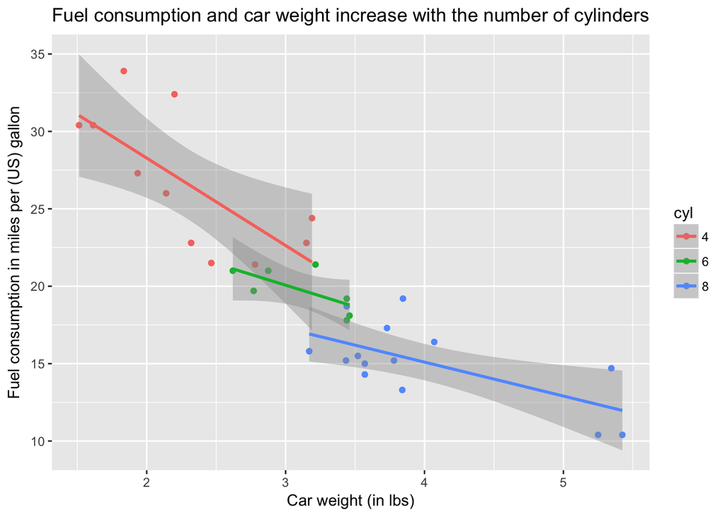

```r
mtcars %>%
  mutate(cyl = factor(cyl)) %>%
  ggplot() +
  geom_point(aes(wt, mpg, color = cyl)) +
  geom_smooth(aes(wt, mpg, color = cyl), method = "lm") +
  ggtitle("Fuel consumption and car weight increase with the number of cylinders") +
  labs(x="Car weight (in lbs)", y="Fuel consumption in miles per (US) gallon")
```

First, let’s consider the relationship between the car weight and its fuel consumption measured by miles per (US) gallon. It seems that the car weight is negatively associated with mpg, meaning that a heavier car will have a lower mpg. In words, it means that the heavier the car, the higher the fuel consumption.

Let’s consider now the relationship between mpg and the number of cylinders. It seems that a higher mpg is linked with cars with 4 cylinders, whereas low mpg is linked to cars with 6 and 8 cylinders. Therefore, fuel consumption increases with the number of cylinders (as shown previously).

Let’s turn our attention to the relation between the car weight and the number of cylinders. It seems that lighter cars are associated with 4 cylinders, whereas heavier cars are associated with 8 cylinders. Note however some overlapping values in terms of cylinders for cars weighting from 2500lbs to 3500lbs.

Finally, if one considers the whole picture, it seems that the relationship between the car weight and mpg is negative within each cylinder group, with a negative tendency being more pronounced in the car group with 4 cylinders.

One can also note that the dispersion in terms of mpg seems to be the bigger in the car group with 4 cylinders whereas the dispersion in terms of car weight seems to be bigger in the car group with 8 cylinders.

**2.j** Using the full dataset, plot the performance (gross horsepower divided by miles per US gallon) as a function of the weight, with a different color for each number of cylinders and a different shape for each type of transmission. What can you conclude about the relationships between the four variables?

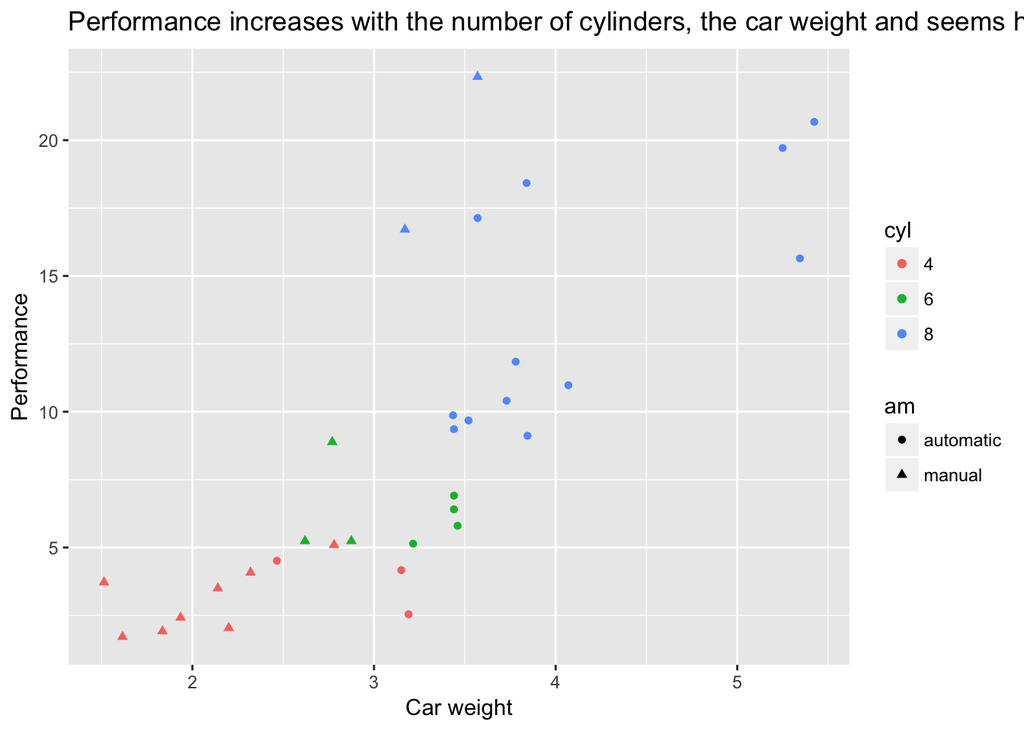

```r
mtcars %>%
    mutate(cyl = factor(cyl),
           am = factor(am, labels = c("automatic", "manual")),
           perf = hp/mpg) %>%
    ggplot() +
    geom_point(aes(wt, perf, color = cyl, pch = am)) +
    ggtitle("Performance increases with the number of cylinders, the car weight and seems higher for automatic cars") +
    labs(x="Car weight", y="Performance")
```

Let’s first discuss the relationship between the car weight and the performance. It seems that the there is here a positive relationship between the two: the performance increases with the car weight. All cars weighting less than 3000lbs have performance below 10; whereas cars weighting more than 5000lbs have performance above 15. For cars between 3000lbs and 4000lbs, the values in terms of performance range from points below 5 to the maximum of the series, above 20.

Let’s now consider the relationship between the number of cylinders and performance. One can see that, the higher the number of cylinders, the higher the performance. If one considers the cars with 4 cylinders, their performance are all below 5. The cars with 6 cylinders have performance ranging from 5 to 10. The cars with 8 cylinders have performance ranging from a bit below 10 to more than 20. Clearly, the relationship is positive between the performance and the number of cylinders.

Let’s then analyse the relationship between the performance and whether the car is manual or automatic. If one is to consider only the automatic cars first, their values in terms of performance range from 2.5 to a bit above 20, with most of their values being above 9. If one considers the manual cars, except for two extremal points, their performance is below 10. In this case, one could consider that there is a relationship between performance and whether the car is automatic or manual. In particular, and at least, it is more likely for a manual car to have lower performance.

The relationship between whether the car is manual or automatic and the car weight can also be considered. Note that all manual cars (except for 2) weight less than 3000lbs and in any case weight less than 3700lbs whereas if one considers automatic cars, they weight more than 3000lbs (except for one value) and more than 50% of it weight more than 3500lbs.

**2.k** Save `cars_cyl` as a `.csv` into the `results` subdirectory in your project.

```
write.csv(cars_cyl, "../results/cars_cyl.csv")
```

#### Exercise 3: Air Quality in New York

In this exercise, you will use the airquality dataset from the `datasets` package. This dataset contains information about air quality measurements in New York between May 1973 and September 1973. A preview of the dataset:

```r
data(airquality)
head(airquality)
```

```
##   Ozone Solar.R Wind Temp Month Day
## 1    41     190  7.4   67     5   1
## 2    36     118  8.0   72     5   2
## 3    12     149 12.6   74     5   3
## 4    18     313 11.5   62     5   4
## 5    NA      NA 14.3   56     5   5
## 6    28      NA 14.9   66     5   6
```

**3.a** Transform the temperature from degrees Farhenheit to degrees Celsius.

```r
airquality <- airquality %>% mutate(Temp = (Temp - 32) * 5 / 9)
```

**3.b** For how many days has the temperature been higher than 30 degrees?

```r
airquality %>%
  filter(Temp > 30) %>%
  nrow()
```

```
## [1] 27
```

**3.c** How many of those days were in July or August?

```r
airquality %>%
  filter(Temp > 30) %>%
  filter(is.element(Month, c(7, 8))) %>%
  nrow()
```

```
## [1] 17
```

**3.d** Display the average monthly temperature.

```r
airquality %>%
  select(Month, Temp) %>%
  group_by(Month) %>%
  summarise(mean(Temp)) %>%
  kable(format="pandoc", caption="July and August are the hottest months, whereas May is the coldest ", col.names=c("Month", "Average temperature"))
```

July and August are the hottest months, whereas May is the coldest

| Month | Average temperature |
| --- | --- |
| 5 | 19 |
| 6 | 26 |
| 7 | 29 |
| 8 | 29 |
| 9 | 25 |

**3.e** Display ten randomly selected observations from the dataset. What happens if you execute your code a few times? How can you make sure that each execution returns the exact 10 rows?

```r
airquality %>%
  sample_n(size = 10) %>%
  kable(format="pandoc", caption="10 observations chosen randomly from the dataset")
```

10 observations chosen randomly from the dataset

|  | Ozone | Solar.R | Wind | Temp | Month | Day |
| --- | --- | --- | --- | --- | --- | --- |
| 131 | 23 | 220 | 10.3 | 26 | 9 | 8 |
| 37 | NA | 264 | 14.3 | 26 | 6 | 6 |
| 19 | 30 | 322 | 11.5 | 20 | 5 | 19 |
| 26 | NA | 266 | 14.9 | 14 | 5 | 26 |
| 39 | NA | 273 | 6.9 | 31 | 6 | 8 |
| 110 | 23 | 115 | 7.4 | 24 | 8 | 18 |
| 113 | 21 | 259 | 15.5 | 25 | 8 | 21 |
| 88 | 52 | 82 | 12.0 | 30 | 7 | 27 |
| 115 | NA | 255 | 12.6 | 24 | 8 | 23 |
| 36 | NA | 220 | 8.6 | 29 | 6 | 5 |

If one is to execute this code multiple times without modifications, the resulting rows picked at random will be different. In order to prevent this, for reproducibility purpose, one can use the `set.seed()`command.

**3.f** Display the number of days in each month.

```r
airquality %>%
  select(Month, Day) %>%
  group_by(Month) %>%
  count %>%
  kable(format="pandoc", caption="Number of days per month", col.names=c("Month", "Number of days"))
```

Number of days per month

| Month | Number of days |
| --- | --- |
| 5 | 31 |
| 6 | 30 |
| 7 | 31 |
| 8 | 31 |
| 9 | 30 |

**3.g** Display the days where the temperature was lower than 20 degrees with observations * where the ozone measurement is missing are removed * and arranged in descending order of the Month and ascending order of Day.

```r
airquality %>%
  filter(Temp < 20) %>%
  filter(!is.na(Ozone)) %>%
  arrange(desc(Month),Day) %>%
  select(Month, Day, everything()) %>%
  kable(format="pandoc", caption="Days with temperatures below 20 degrees are common in May")
```

Days with temperatures below 20 degrees are common in May

| Month | Day | Ozone | Solar.R | Wind | Temp |
| --- | --- | --- | --- | --- | --- |
| 9 | 17 | 18 | 224 | 13.8 | 19 |
| 9 | 21 | 13 | 238 | 12.6 | 18 |
| 9 | 25 | 14 | 20 | 16.6 | 17 |
| 6 | 18 | 20 | 37 | 9.2 | 18 |
| 5 | 1 | 41 | 190 | 7.4 | 19 |
| 5 | 4 | 18 | 313 | 11.5 | 17 |
| 5 | 6 | 28 | NA | 14.9 | 19 |
| 5 | 7 | 23 | 299 | 8.6 | 18 |
| 5 | 8 | 19 | 99 | 13.8 | 15 |
| 5 | 9 | 8 | 19 | 20.1 | 16 |
| 5 | 13 | 11 | 290 | 9.2 | 19 |
| 5 | 15 | 18 | 65 | 13.2 | 14 |
| 5 | 16 | 14 | 334 | 11.5 | 18 |
| 5 | 17 | 34 | 307 | 12.0 | 19 |
| 5 | 18 | 6 | 78 | 18.4 | 14 |
| 5 | 20 | 11 | 44 | 9.7 | 17 |
| 5 | 21 | 1 | 8 | 9.7 | 15 |
| 5 | 23 | 4 | 25 | 9.7 | 16 |
| 5 | 24 | 32 | 92 | 12.0 | 16 |
| 5 | 28 | 23 | 13 | 12.0 | 19 |

**3.h** Produce monthly boxplots of temperature. More specifically, your figure should contain 5 boxplots (i.e., one for each month), with months as the x-axis and the temperature as the y-axis. What can you say about the monthly temperature evolution?

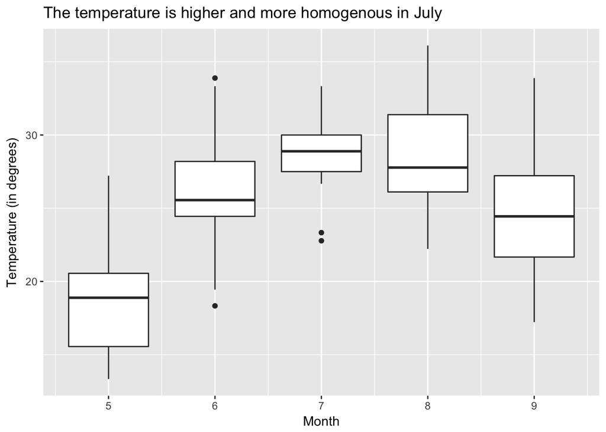

```r
airquality %>%
  ggplot(aes(Month, Temp, group = Month)) +
  geom_boxplot() +
  ggtitle("The temperature is higher and more homogenous in July ") +
  labs(y="Temperature (in degrees)")
```

All in all, there is a peak in the median temperature at the midst of Summer (in July) and July is also the hottest month in terms of median temperature.

**3.i** For the days where such data is available, create a scatter plot of the ozone concentration per month. Add the monthly averages in a different color as well as a line that connects them. What can you say about the relationship between Ozone and Month? Is there any similarity to the pevious plot? Describe the link between temperature, ozone and month.

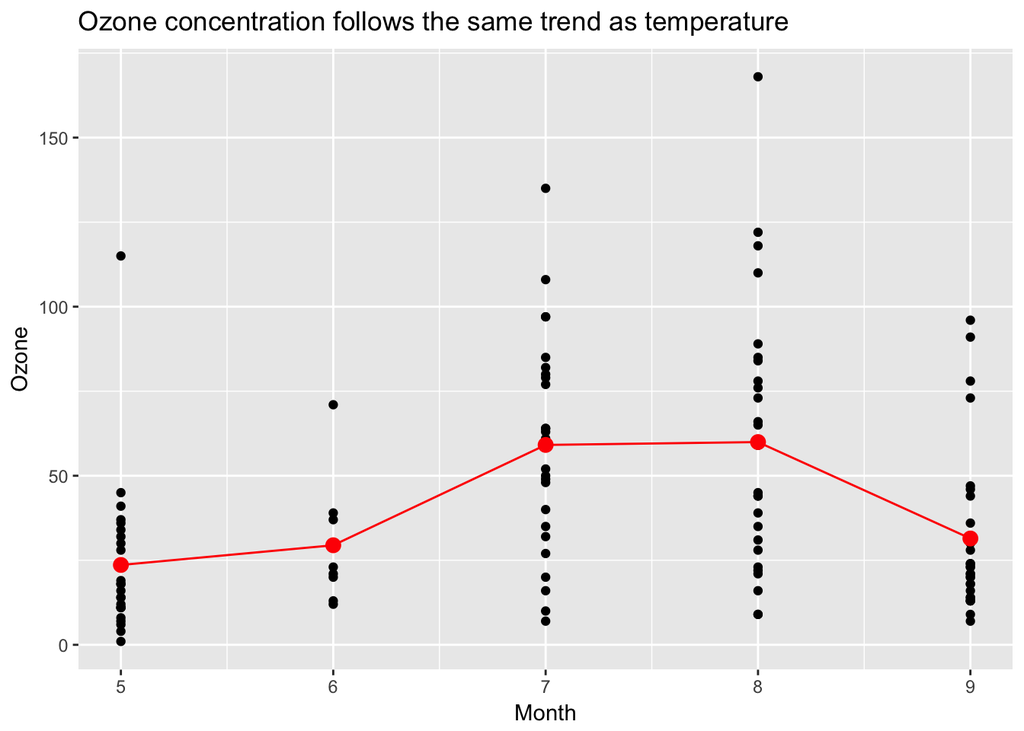

```r
airquality %>%
  filter(!is.na(Ozone)) %>%
  ggplot(aes(Month, Ozone)) +
  geom_point() +
  stat_summary(fun.y = "mean", na.rm = TRUE,
               geom = "point", color = "red", size = 3) +
  stat_summary(fun.y = "mean", na.rm = TRUE, geom = "line", color = "red") +
  ggtitle("Ozone concentration follows the same trend as temperature")
```

The trend followed by the average ozone concentration per month is similar to the trend followed by the median temperature per month. It reaches spikes in July and August, meaning that the ozone concentration is higher in the midst of Summer (July and August) when compared to May and September.

Note in addition that there is a wider dispersion in terms of ozone concentration in July and August than in May and September, for example.

Note also that June seems to have less available data than the other months. This average should therefore be treated carefully.